# Phenomenal Plots

Chirag Kumar

## Introduction

Plotting is a powerful tool that can show hidden relationships between two variables. In this document, I explore the power of plotting to create incredible and mind-boggling designs.

## Plots!

### Some basic plots

Let’s start off with a simple plot. Traditionally, I have always plotted by creating an x-vector, applying my function to it, and getting the y-vector. I then use the *plot()* command to see the relation between my vectors. For example:

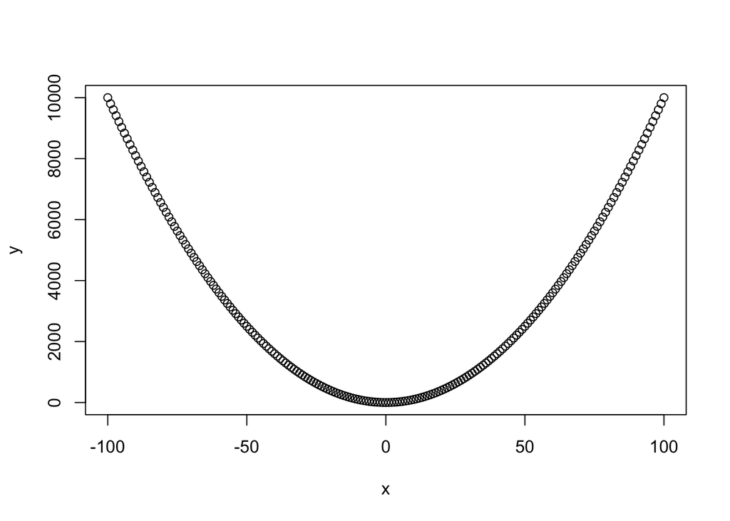

```r
x <- seq(from = -100, to = 100, by = 1)
y <- x^2
plot(x, y)
```

This plot shows the function $y = x^{2}$.

We can get more complex and create a plot in 3D but only show 2 Dimensions. For example, we will plot $x = sin(2t), y = sin(3t)$ but not have a *t-axis*. Take a look:

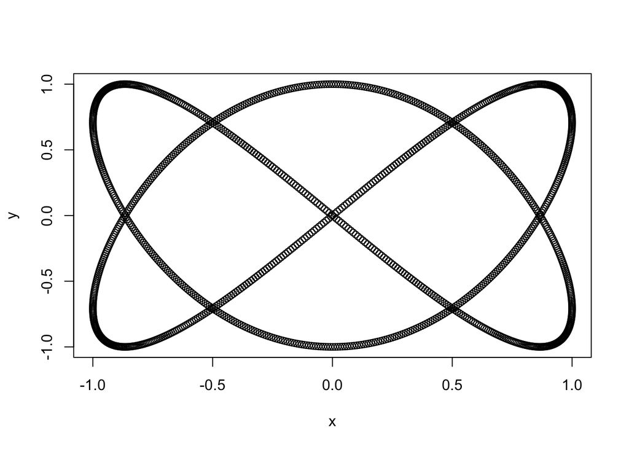

```r
t <- seq(from = 0, to = 2*pi, by = .005)
x <- sin(2*t)
y <- sin(3*t)
plot(x, y)
```

This is a pretty cool plot and incredible designs can be made using the basic trigonometry functions.

### Graphs from Trig Functions

#### The Fish Curve and *curve()*

Rather than using the *plot()* function which requires x and y vectors as input and creates a scatter plot, I will instead use the *curve()* function. The *curve()* function creates a continuous curve based on given equation.

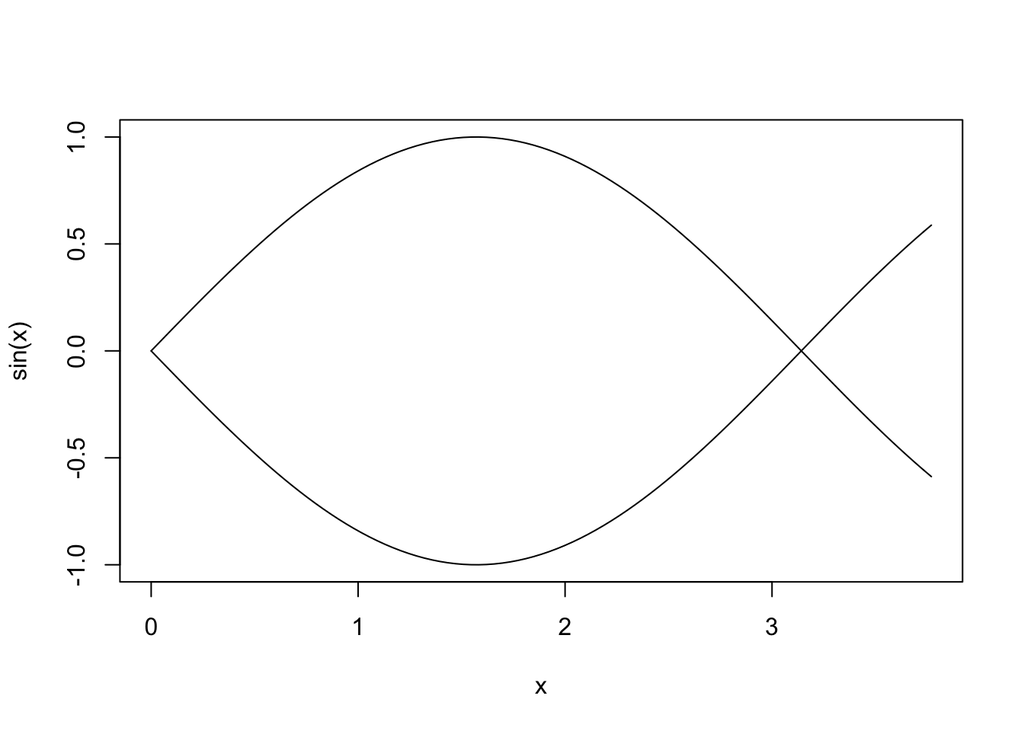

```r
curve(sin(x), from = 0, to = 1.2*pi, xlim = c(0, 1.2*pi), ylim = c(-1, 1))
curve(-sin(x), from = 0, to = 1.2*pi, add = TRUE)
```

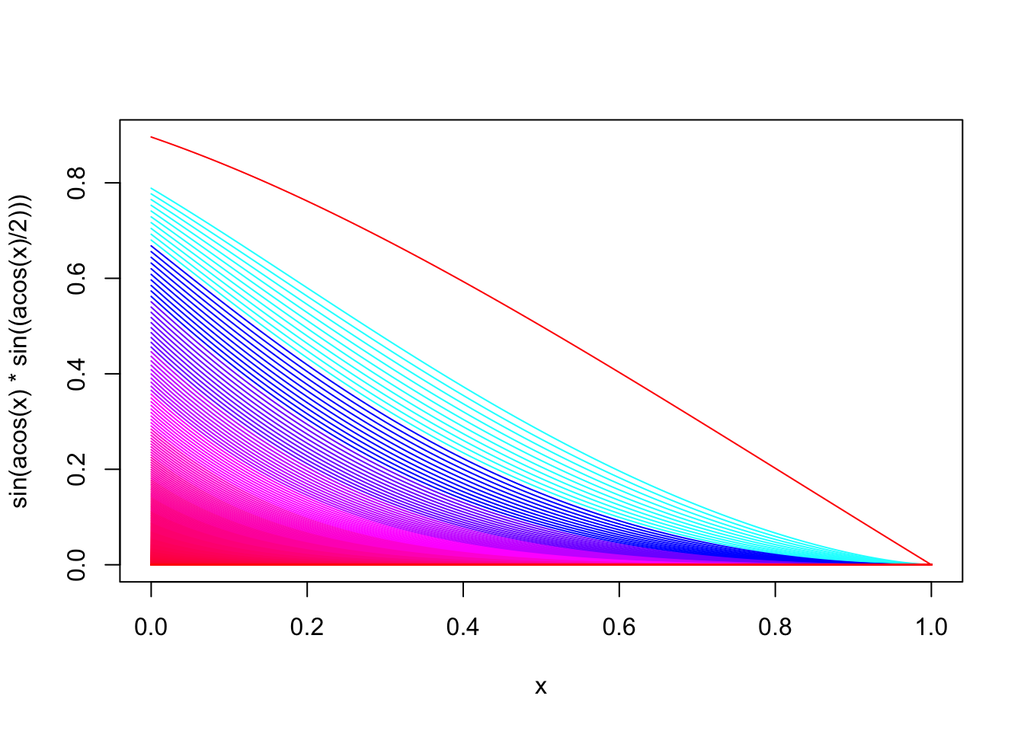

```r
curve(sin(acos(x) * sin((acos(x)/2))), col = rainbow(1))
for(j in seq(2, 500, by = .1)) {
  curve(sin(acos(x) * sin((acos(x)/2)^j)), col = rainbow(j)[j], add = TRUE)
}
```

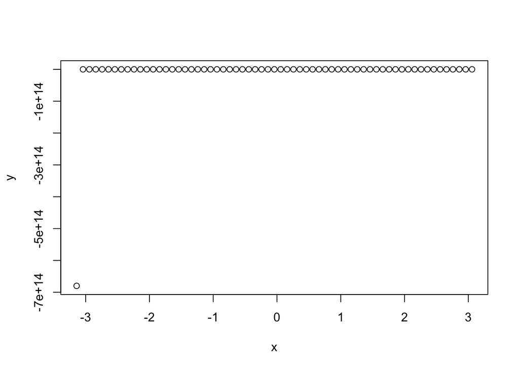

```r
x <- seq(from = -pi, to = pi, by = .1)
y <- tan(17*x) + 1/(tan(17*x))
plot(x, y)
```